# 326.212 Homework 4

Dongwon Kim

```r
library(tidyverse)
library(stringr)
library(modelr)
library(nycflights13)
options(na.action = na.warn)
```

## 2020-13483

### Textbook 19.3.1

#### Problem 1. Read the source code for each of the following three functions, puzzle out what they do, and then brainstorm better names.

```r
f1 <- function(string, prefix) {
  substr(string, 1, nchar(prefix)) == prefix
}
f2 <- function(x) {
  if (length(x) <= 1) return(NULL)
  x[-length(x)]
}
f3 <- function(x, y) {
  rep(y, length.out = length(x))
}
```

f1은 “string”에 속하는 문자열들이 “prefix”에 해당하는 접두사 문자열을 포함하고 있는지 확인하는 함수이다. 그러므로 이름을 include_prefix()로 함수 이름을 바꾸어도 좋을것이다.

f2는 벡터“x”에서 가장 마지막에 있는 것을 없애는 함수이다.(만약 x의 길이가 1이라면 Null이 나옴) 그러므로 delete_last()로 바꾸어도 좋을 것이다.

f3는 y를 반복하는데 이 때의 길이가 x의 길이와 동일할 때까지만 반복하는 함수이다. 그러므로 이름을 expand_to_x()로 바꾸어도 좋을 것이다.

### Textbook 19.4.4

#### Problem 1. What’s the difference between if and ifelse()? Carefully read the help and construct three examples that illustrate the key differences.

```r
x <- 2
sqrt(ifelse(c(x >= 0,x <= 3), x, NA))
```

```
## [1] 1.414214 1.414214
```

```r
if(c(x >= 0,x <= 3)) {sqrt(x)} #example 1 여기서 1번째 조건을 만족하므로 실행되었지만 if는 그 뒤의 조건이 만족되더라도 테스트 안하므로 2번째 조건 관련해서는 아무것도 실행되지 않았다.
```

```
## [1] 1.414214
```

```r
age <- c(10,20,30,60,70,80)
ifelse(c(age >= 65, age <= 13), "socially weak", "normal")
```

```
##  [1] "normal"        "normal"        "normal"        "normal"
##  [5] "socially weak" "socially weak" "socially weak" "normal"
##  [9] "normal"        "normal"        "normal"        "normal"
```

```r
if(c(age >= 10,x <= 90)) {print("socially weak")} #example 2 여기서 1번째 조건을 만족하므로 실행되었지만 if는 그 뒤의 조건은 테스트 안하므로 2번째 조건 관련해서는 아무것도 실행되지 않았다. 여기까지는 example1과 같으나 example 2에서 찾을 수 있는 if와 ifelse()의 다른점은 if와 다르게 ifelse()에서는 각 요소마다 조건 충족여부를 따져준다는 것을 확인해볼 수 있다는 것이다. if는 그와 다르게 모든 요소가 조건을 만족하는지 안하는지를 따진다.
```

```
## [1] "socially weak"
```

```r
x <- 3
if(x<=2){sqrt(x)}
ifelse(x<=2,sqrt(x),exp(x)) #example3 if만으로는 조건을 만족할때만 실행되지만 (else를 사용하지 않는 경우) ifelse()는 조건 만족 여부와 관계없이 항상 작동한다.
```

```
## [1] 20.08554
```

#### Problem 6. What does this switch() call do? What happens if x is “e”? Experiment, then carefully read the documentation.

```r
x<-"a"
switch(x,
  a = ,
  b = "ab",
  c = ,
  d = "cd"
)
```

```
## [1] "ab"
```

```r
x<-"e"
switch(x,
  a = ,
  b = "ab",
  c = ,
  d = "cd"
)
```

switch()는 문자열과 정확히 일치하는 이름이 있다면 그 이름에 해당하는 값으로 바뀐다. 만약 어떤 이름에 해당하는 값이 없다면 그 뒤에 있는 값을 가져와 사용한다. 하지만 문자열과 정확히 일치하는 이름이 없다면 아무일도 나타나지 않는다. 그러므로 x가 “e”이면 아무일도 나타나지 않는다.

### Textbook 19.5.5

#### Problem 4. The default value for the method argument to cor() is c(“pearson”, “kendall”, “spearman”). What does that mean? What value is used by default?

상관계수를 구하는 cor() 함수에 대한 `method`인수가 이 세 가지 중 하나의 방법론을 취할 수 있다는 뜻이다. 이 중에서 첫 번째 것인 “pearson”이 기본적으로 사용된다.

### Textbook 20.3.5

#### Problem 2. Read the source code for dplyr::near() (Hint: to see the source code, drop the ()). How does it work?

```r
dplyr::near
```

```
## function (x, y, tol = .Machine$double.eps^0.5)
## {
##     abs(x - y) < tol
## }
## <bytecode: 0x000000001473ea28>
## <environment: namespace:dplyr>
```

정확히 같은지를 확인하는 대신 두 숫자가 특정 허용오차 안에 있는지 확인한다. 기본적으로 허용오차는 컴퓨터가 나타낼 수 있는 가장 작은 소수점 수인 `.Machine$double.eps`의 제곱근으로 설정된다.

### Textbook 20.5.4

#### Problem 1. Draw the following lists as nested sets:

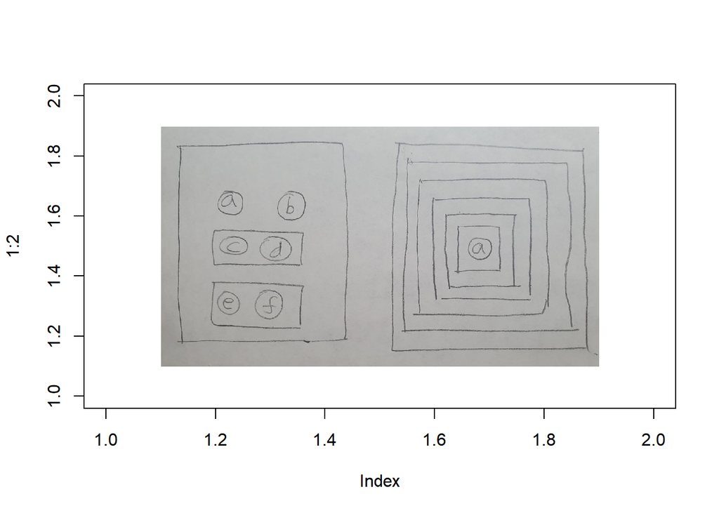

```r
library(jpeg)
setwd(file.path("C:", "Users", "r english", "Documents", "GitHub", "sc20-hw-chamchi-god", "hw4", "etc"))
a<-readJPEG("image.jpg")
plot(1:2, type='n')
rasterImage(as.raster(a), 1.1, 1.1, 1.9, 1.9, interpolate=FALSE)
```

```r
#왼쪽이 1번 오른쪽이 2번
```

### Textbook 20.7.4

#### Problem 2. Try and make a tibble that has columns with different lengths. What happens?

```r
tibble(x = 1, y = 5:1)
```

```
## # A tibble: 5 x 2
##       x     y
##   <dbl> <int>
## 1     1     5
## 2     1     4
## 3     1     3
## 4     1     2
## 5     1     1
```

```r
#tibble(x = 1:2, y = 5:1)
```

스칼라와 다른 길이의 벡터를 이용해 `tibble`을 만들고자 하면 오류 없이 스칼라가 여러번 반복되며 `tibble`이 만들어진다. 하지만 스칼라가 아닌 서로 다른 길이의 벡터를 이용해 `tibble`을 만들려고 하면 오류가 발생한다.

#### Problem 3 .Based on the definition above, is it ok to have a list as a column of a tibble?

`tibble`은 데이터 프레임의 모든 요소가 길이가 같은 벡터여야 하기 때문에 `list`가 `tibble`의 열로서 다른 열들과 같은 길이를 같고 있다면 가능할 것이라 생각된다.

### Textbook 21.2.1

#### Problem 2. Eliminate the for loop in each of the following examples by taking advantage of an existing function that works with vectors:

```r
out <- ""
for (x in letters) {
  out <- stringr::str_c(out, x)
}

x <- sample(100)
sd <- 0
for (i in seq_along(x)) {
  sd <- sd + (x[i] - mean(x)) ^ 2
}
sd <- sqrt(sd / (length(x) - 1))

x <- runif(100)
out <- vector("numeric", length(x))
out[1] <- x[1]
for (i in 2:length(x)) {
  out[i] <- out[i - 1] + x[i]
}
```

1. str_c(letters, collapse = "")
2. sd(x)
3. cumsum(x)

### Textbook 21.3.5

#### Problem 3. Write a function that prints the mean of each numeric column in a data frame, along with its name. For example, show_mean(iris) would print:

```r
show_mean <- function(x) {

  real_num <- vector("logical", length(x))
  for (i in seq_along(x)) real_num[[i]] <- is.numeric(x[[i]])

  x <- x[real_num]
  max<-max(str_length(names(x)))

  for (i in seq_along(x)) { if(str_length(names(x)[i])<max){ cat(str_c(names(x)[i], ":  ", format(mean(x[[i]]), digits =  2, nsmall = 2)), fill = TRUE)} else
  cat(str_c(names(x)[i], ": ", format(mean(x[[i]]), digits =  2, nsmall = 2)), fill = TRUE)
  }
}

show_mean(iris)
```

```
## Sepal.Length: 5.84
## Sepal.Width:  3.06
## Petal.Length: 3.76
## Petal.Width:  1.20
```

### Textbook 21.4.1

#### Problem 1.Read the documentation for apply(). In the 2d case, what two for loops does it generalise?

```r
a <- cbind(x1 = 3, x2 = c(4:1, 2:5))
apply(a, 1, sum)
```

```
## [1] 7 6 5 4 5 6 7 8
```

```r
apply(a, 2, sum)
```

```
## x1 x2
## 24 24
```

```r
a_row_sum <- vector("numeric", length = nrow(a))
for (i in seq_len(nrow(a))) {
  a_row_sum[[i]] <- sum(a[i, ])
}
a_row_sum
```

```
## [1] 7 6 5 4 5 6 7 8
```

```r
a_col_sum <- vector("numeric", length = ncol(a))
for (i in seq_len(ncol(a))) {
  a_col_sum[[i]] <- sum(a[,i ])
}
a_col_sum # case 1 Compute row and column sums for a matrix
```

```
## [1] 24 24
```

```r
apply(a, 1, sort)
```

```
##      [,1] [,2] [,3] [,4] [,5] [,6] [,7] [,8]
## [1,]    3    3    2    1    2    3    3    3
## [2,]    4    3    3    3    3    3    4    5
```

```r
apply(a, 2, sort)
```

```
##      x1 x2
## [1,]  3  1
## [2,]  3  2
## [3,]  3  2
## [4,]  3  3
## [5,]  3  3
## [6,]  3  4
## [7,]  3  4
## [8,]  3  5
```

```r
a_row_sort <- list("numeric", length = nrow(a))
for (i in seq_len(nrow(a))) {
  a_row_sort[[i]] <- sort(a[i, ])
}
num1<-as.numeric(unlist(a_row_sort))
print(matrix(num1, byrow = F, nrow = ncol(a)))
```

```
##      [,1] [,2] [,3] [,4] [,5] [,6] [,7] [,8]
## [1,]    3    3    2    1    2    3    3    3
## [2,]    4    3    3    3    3    3    4    5
```

```r
a_col_sort <- list("numeric", length = ncol(a))
for (i in seq_len(ncol(a))) {
  a_col_sort[[i]] <- sort(a[,i ])
}
num2<-as.numeric(unlist(a_col_sort))
print(matrix(num2,byrow = F ,ncol = ncol(a) )) #case 2 Sort the columns of a matrix
```

```
##      [,1] [,2]
## [1,]    3    1
## [2,]    3    2
## [3,]    3    2
## [4,]    3    3
## [5,]    3    3
## [6,]    3    4
## [7,]    3    4
## [8,]    3    5
```

### Textbook 21.5.3

#### Problem 1. Write code that uses one of the map functions to:

Compute the mean of every column in mtcars. Determine the type of each column in nycflights13::flights. Compute the number of unique values in each column of iris. Generate 10 random normals from distributions with means of -10, 0, 10, and 100.

```r
map_dbl(mtcars, mean) #1
```

```
##        mpg        cyl       disp         hp       drat         wt       qsec
##  20.090625   6.187500 230.721875 146.687500   3.596563   3.217250  17.848750
##         vs         am       gear       carb
##   0.437500   0.406250   3.687500   2.812500
```

```r
map_chr(nycflights13::flights, typeof) #2
```

```
##           year          month            day       dep_time sched_dep_time
##      "integer"      "integer"      "integer"      "integer"      "integer"
##      dep_delay       arr_time sched_arr_time      arr_delay        carrier
##       "double"      "integer"      "integer"       "double"    "character"
##         flight        tailnum         origin           dest       air_time
##      "integer"    "character"    "character"    "character"       "double"
##       distance           hour         minute      time_hour
##       "double"       "double"       "double"       "double"
```

```r
map_int(iris, function(x) length(unique(x))) #3
```

```
## Sepal.Length  Sepal.Width Petal.Length  Petal.Width      Species
##           35           23           43           22            3
```

```r
map(c(-10, 0, 10, 100), ~ rnorm(n = 10, mean = .)) #4
```

```
## [[1]]
##  [1] -10.960873 -10.358673 -10.711658 -10.974698 -10.538527  -9.491592
##  [7] -11.213147 -10.494887  -8.516845 -10.506763
##
## [[2]]
##  [1]  0.7423681  0.1763187 -0.6717821  0.1275919 -0.2493368 -0.1624103
##  [7]  0.3090322  0.6139525  0.4198916 -1.6147591
##
## [[3]]
##  [1]  9.367695  9.457778 10.663729  8.402519 10.602624  9.482059 11.121466
##  [8]  9.721262 10.890631  8.857936
##
## [[4]]
##  [1]  99.75134 100.53794  99.25745  99.75596  98.96537  99.33162  99.09318
##  [8]  99.62232  99.27348  99.24201
```

### Textbook 21.9.3

#### Problem 3. A possible base R equivalent of col_summary() is:

```r
col_sum3 <- function(df, f) {
  is_num <- sapply(df, is.numeric)
  df_num <- df[, is_num]

  sapply(df_num, f)
}
```

#### But it has a number of bugs as illustrated with the following inputs:

```r
df <- tibble(
  x = 1:3,
  y = 3:1,
  z = c("a", "b", "c")
)
# OK
col_sum3(df, mean)
```

```
## x y
## 2 2
```

```r
# Has problems: don't always return numeric vector
col_sum3(df[1:2], mean)
```

```
## x y
## 2 2
```

```r
col_sum3(df[1], mean)
```

```
## x
## 2
```

```r
#col_sum3(df[0], mean) 버그 발생
```

#### What causes the bugs?

이 상황에서는 sapply()로 인해 버그가 발생하고 있다. sapply()는 열을 선택하지 않는다면 빈 `list` 형태로 output을 출력한다. 여기서 문제가 되는 이유는 [] 안에서는 벡터가 `logical`, `numeric` 또는 `character`타입일때만 실행이 가능한데, sapply()로 인해 `list` 형태로 `is_num`이 출력되어 실행이 안되는 문제가 발생하고 있다.

### Textbook 23.4.5

#### Problem 1. What happens if you repeat the analysis of sim2 using a model without an intercept. What happens to the model equation? What happens to the predictions?

```r
model_matrix(sim2, y ~ x)
```

```
## # A tibble: 40 x 4
##    `(Intercept)`    xb    xc    xd
##            <dbl> <dbl> <dbl> <dbl>
##  1             1     0     0     0
##  2             1     0     0     0
##  3             1     0     0     0
##  4             1     0     0     0
##  5             1     0     0     0
##  6             1     0     0     0
##  7             1     0     0     0
##  8             1     0     0     0
##  9             1     0     0     0
## 10             1     0     0     0
## # ... with 30 more rows
```

```r
model_matrix(sim2, y ~ x - 1)
```

```
## # A tibble: 40 x 4
##       xa    xb    xc    xd
##    <dbl> <dbl> <dbl> <dbl>
##  1     1     0     0     0
##  2     1     0     0     0
##  3     1     0     0     0
##  4     1     0     0     0
##  5     1     0     0     0
##  6     1     0     0     0
##  7     1     0     0     0
##  8     1     0     0     0
##  9     1     0     0     0
## 10     1     0     0     0
## # ... with 30 more rows
```

```r
mod2<- lm( y ~x  , data = sim2)
mod2_i<- lm( y ~x -1 , data = sim2)
grid <- sim2 %>%
  data_grid(x) %>%
  gather_predictions(mod2,mod2_i)
grid
```

```
## # A tibble: 8 x 3
##   model  x      pred
##   <chr>  <chr> <dbl>
## 1 mod2   a      1.15
## 2 mod2   b      8.12
## 3 mod2   c      6.13
## 4 mod2   d      1.91
## 5 mod2_i a      1.15
## 6 mod2_i b      8.12
## 7 mod2_i c      6.13
## 8 mod2_i d      1.91
```

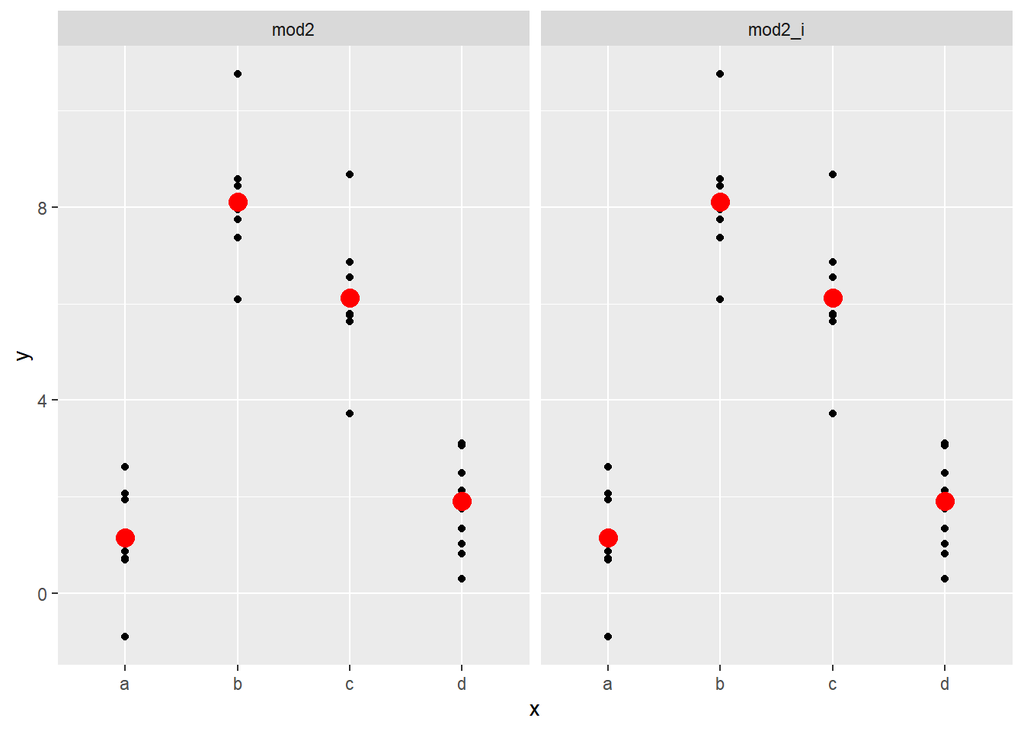

```r
sim2 %>%
  ggplot(aes(x))+
  geom_point(aes(y=y))+
  geom_point(data = grid, aes(y = pred),color = "red",size = 4)+
  facet_grid(~model)
```

model equation을 알아보고자 `model_matrix`를 사용한 결과 intercept를 없애주지 않았을 때에는 xa열이 없고 intercept열이 있었는데, intercept를 -1을 통해 없애니 intercept열이 사라지고 xa열이 생겨났다. 그리고 intercept의 유무와 관련없이 예측값들에는 변화가 없다.

### Textbook 24.2.3

#### Problem 2. If log(price) = a_0 + a_1 * log(carat), what does that say about the relationship between price and carat?

```r
lm_dia<-lm(log(price) ~ log(carat), data = diamonds)
lm_dia
```

```
##
## Call:
## lm(formula = log(price) ~ log(carat), data = diamonds)
##
## Coefficients:
## (Intercept)   log(carat)
##       8.449        1.676
```

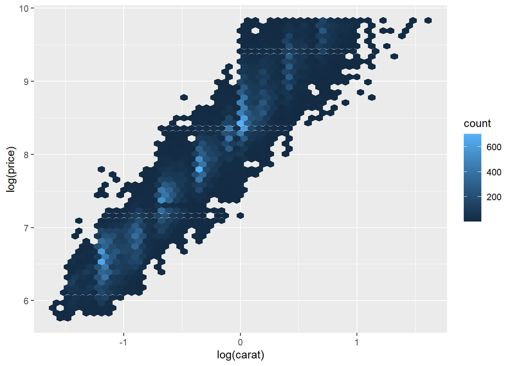

```r
ggplot(diamonds, aes(log(carat), log(price))) +
  geom_hex(bins = 50) #선형
```

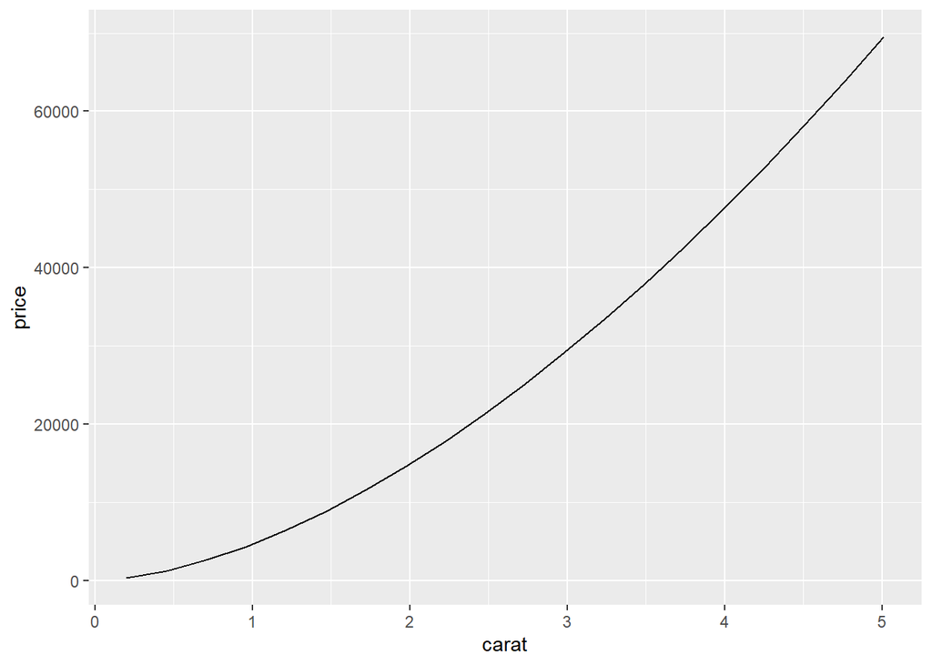

```r
diamonds %>%
  data_grid(carat = seq_range(carat, 20)) %>%
 add_predictions(lm_dia) %>%
 ggplot(aes(x = carat, y = exp(1)^pred)) +
 geom_line() +
 labs(x = "carat", y = "price") # carat이 커질수록 price는 기하급수적으로 커지는 모습
```

log scale에서 carat과 price의 관계를 그려낸 그래프를 보면 선형의 비례관계를 갖는 것으로 보인다. `lm(log(price) ~ log(carat), data = diamonds)` 결과 로그 스케일에서 캐럿이 1만큼 커질수록 가격이 1.6만큼 커진다는 것을 확인할 수 있었다. 하지만 이를 실제 scale로 가져와서 고려해본다면 carat이 커지는 것보다 price는 더 기하급수적으로 커지는 모습을 확인할 수 있다.

### Textbook 24.3.5

#### Problem 2. What do the three days with high positive residuals represent? How would these days generalise to another year?

```r
#daily %>%  slice_max(n = 3, resid)
```

```
#> # A tibble: 3 x 5
#>   date           n wday  resid term
#>   <date>     <int> <ord> <dbl> <fct>
#> 1 2013-11-30   857 Sat   112.  fall
#> 2 2013-12-01   987 Sun    95.5 fall
#> 3 2013-12-28   814 Sat    69.4 fall
```

해당하는 3일은 추수감사절 이후의 토요일(11월 30일), 추수감사절 이후의 일요일(12월 1일), 크리스마스 이후의 토요일(12월 28일)에 해당한다. 우리는 그 해의 공휴일 날짜를 사용하여 이것을 공휴일 날짜와 가까운 주말에 `high positive residuals`를 가진다는 것을 일반화할 수 있을 것이다.

### Textbook Extra question(s)

#### Problem 1. (Data manipulation)

#### a.For the R built-in iris dataset, the following R code is given:

```r
 data(iris)
 swidth.versicolor <- NULL
 for (i in seq_len(nrow(iris)) ) {
         if (iris$Species[i]=="versicolor") {
                 swidth.versicolor <- c(swidth.versicolor, iris$Sepal.Width[i])
         }
 }
```

#### Vectorize the above code.

```r
    ver<- iris$Species=="versicolor"
       iris$Sepal.Width[ver]
```

```
##  [1] 3.2 3.2 3.1 2.3 2.8 2.8 3.3 2.4 2.9 2.7 2.0 3.0 2.2 2.9 2.9 3.1 3.0 2.7 2.2
## [20] 2.5 3.2 2.8 2.5 2.8 2.9 3.0 2.8 3.0 2.9 2.6 2.4 2.4 2.7 2.7 3.0 3.4 3.1 2.3
## [39] 3.0 2.5 2.6 3.0 2.6 2.3 2.7 3.0 2.9 2.9 2.5 2.8
```

#### b. Type and run the following R code.

```r
 data(iris)
 head(iris$Sepal.Length[iris$Species])
```

```
## [1] 5.1 5.1 5.1 5.1 5.1 5.1
```

#### Explain why you get those results.

x[i]에서 i가 factor형태이면 그 결과는 as.integer(iris$Species)와 동일하게 된다. 그러므로 이 문제에서 Species value의 종류는 3가지 이므로 value에 따라 1,2,3으로 나오게 될 것이다. 즉, `iris$Sepal.Length[iris$Species]`에서 [iris$Species]는 Species value종류에 따라 [1],[2],[3]과 다를 바가 없어서 위와같은 결과를 얻는다. 가장 먼저나오는 Species value인 setosa가 [1]역할을 하여 50행까지 iris$Species가 setosa이므로 iris$Sepal.Length[1]인 5.1이 50개 존재하고 그 뒤에 다른 값들이 나올 것이다. 그래서 head(iris$Sepal.Length[iris$Species])을 실행했을 때 5.1 5.1 5.1 5.1 5.1 5.1이 출력된다.

#### Problem 2. (Closure) Simply speaking, a closure is a function created by another function.

#### a.Guess the output of the following code and explain why you get those results.

```r
power <- function(exponent) {
   function(x) {
     x ^ exponent
   }
 }

 square <- power(2)
 square(2)
```

```
## [1] 4
```

```r
 square(4)
```

```
## [1] 16
```

```r
 cube <- power(3)
 cube(2)
```

```
## [1] 8
```

```r
 cube(4)
```

```
## [1] 64
```

외부의 function(exponent)에 의해 power(z)에서 z에 해당하는 값에 따라 exponent값이 결정된다. 그러므로 exponent값이 결정되면 이제 앞서 정해진 것들을 이용해 내부의 function(x)가 작동하게 된다. (내부 함수의 x값은 처음엔 주어지지 않음 그래서 power만 돌리면 output이 나오지 않는다.) 그러므로 square<-power(2)가 의미하는 바는 square(x)에서 x에 해당하는 값에 제곱을 해준다는 의미이므로 square(2)와 square(4)는 각각 4와 16이 나온다. 마찬가지로 cube<-power(3)가 의미하는 바는 cube(y)에서 y에 해당하는 값에 세제곱을 해준다는 의미이므로 cube(2)와 cube(4)는 각각 8와 64가 나온다.

#### b.What do you think the call k() will return? Explain.

```r
j <- function(x) {
   y <- 2
   function() {
     c(x, y)
   }
}

 k <- j(1)
 k()
```

```
## [1] 1 2
```

j(1)에서 외부의 함수 function(x)에 의해 x값이 1로 정해지고, 이 함수에서 y도 2로 정해진다. 이제 function(x)에 의해 정해진 것들을 이용해 k()에서 이 것들을 다시 내부의 함수 function(#앞서 정해진 x,y값) { c(x, y) }에 적용하게 되어 c(1,2) 만 남을것이고, 출력될때에는 1 2만 나올 것이다.